# ca_supp_1

od

1/16/2020

## Loading required pacakges to laod datasets, manipulate and explore some outputs

## Reading datasets in R with h5ls

```r
h5ls("DataSets/output.hdf")
```

```
##   group          name       otype  dclass         dim
## 0     /          data   H5I_GROUP
## 1 /data         axis0 H5I_DATASET  STRING        1382
## 2 /data  axis1_label0 H5I_DATASET INTEGER        3998
## 3 /data  axis1_label1 H5I_DATASET INTEGER        3998
## 4 /data  axis1_level0 H5I_DATASET   FLOAT         200
## 5 /data  axis1_level1 H5I_DATASET   FLOAT          10
## 6 /data  block0_items H5I_DATASET  STRING        1382
## 7 /data block0_values H5I_DATASET   FLOAT 1382 x 3998
```

## EDA 1:

- The first file (renamed here ‘axis_0’) and the ‘items’ file are similar with dimensions = 1382
- Files label0, label1, level0 and level1 have 3998, 3998, 200 and 10 elements respectivily.
- files renamed here ‘values’ is the only one in array shape with dimensions (1382, 3998)

Question: how are the 4 files [label0, label1, level0 and level1] related to the other files?

```r
h5read("DataSets/output.hdf", name = "data/axis0")  -> axis_0
h5read("DataSets/output.hdf", name = "data/axis1_label0")  -> label0
h5read("DataSets/output.hdf", name = "data/axis1_label1")  -> label1
h5read("DataSets/output.hdf", name = "data/axis1_level0")  -> level0
h5read("DataSets/output.hdf", name = "data/axis1_level1")  -> level1
h5read("DataSets/output.hdf", name = "data/block0_items")  -> items
h5read("DataSets/output.hdf", name = "data/block0_values") -> values
```

```r
axis_0 %>% dim()
```

```
## [1] 1382
```

```r
label0 %>% dim()
```

```
## [1] 3998
```

```r
label1 %>% dim()
```

```
## [1] 3998
```

```r
level0 %>% dim()
```

```
## [1] 200
```

```r
level1 %>% dim()
```

```
## [1] 10
```

```r
items %>% dim()
```

```
## [1] 1382
```

```r
values %>% dim()
```

```
## [1] 1382 3998
```

```r
axis_0 %>% head
```

```
## [1] "total_population_untracked"
## [2] "total_population_tracked"
## [3] "total_population"
## [4] "death_due_to_neonatal_preterm_birth_among_male_in_age_group_early_neonatal"
## [5] "death_due_to_neonatal_preterm_birth_among_female_in_age_group_early_neonatal"
## [6] "death_due_to_neonatal_preterm_birth_among_male_in_age_group_late_neonatal"
```

```r
label0 %>% head
```

```
## [1] 188 122  26  90  82  41
```

```r
label1 %>% head
```

```
## [1] 9 9 1 5 1 7
```

```r
level0 %>% head
```

```
## [1]  1  3  8 14 21 29
```

```r
level1 %>% head
```

```
## [1]  0  2 30 38 43 58
```

```r
items %>% head
```

```
## [1] "total_population_untracked"
## [2] "total_population_tracked"
## [3] "total_population"
## [4] "death_due_to_neonatal_preterm_birth_among_male_in_age_group_early_neonatal"
## [5] "death_due_to_neonatal_preterm_birth_among_female_in_age_group_early_neonatal"
## [6] "death_due_to_neonatal_preterm_birth_among_male_in_age_group_late_neonatal"
```

```r
values[1:10]
```

```
##  [1]  9623 12221 21844   120    74     4     7     2     2     0
```

## Data wrangling process:

- After viewing the file in PYTHON, I realised that ‘items’ file contains the rows names from the orginal dataset.
- That is what I tried to replicate in the following section using only values file and items file.
  - first step: transpose the array (rows-to-columns)
  - second step: add ‘items’ containt as columns names
- output: draft_1

```r
t_values <- t(values)
colnames(t_values) <- items
t_values[c(1:3), c(1:3)]
```

```
##      total_population_untracked total_population_tracked total_population
## [1,]                       9623                    12221            21844
## [2,]                       9561                    12061            21622
## [3,]                       9626                    12081            21707
```

```r
t_values[c(1:3), c(1380:1382)]
```

```
##      low_birth_weight_and_short_gestation_cat212_exposed_in_2024_among_1_to_4
## [1,]                                                                      NaN
## [2,]                                                                        2
## [3,]                                                                      NaN
##      simulation_run_time calcium_supplementation_intervention.proportion
## [1,]            9960.960                                               0
## [2,]            9948.302                                               1
## [3,]           10118.156                                               1
```

```r
draft_1 <- as_tibble(t_values)
draft_1
```

```
## # A tibble: 3,998 x 1,382
##    total_populatio… total_populatio… total_population death_due_to_ne…
##               <dbl>            <dbl>            <dbl>            <dbl>
##  1             9623            12221            21844              120
##  2             9561            12061            21622               95
##  3             9626            12081            21707               90
##  4             9599            11822            21421               94
##  5             9529            12333            21862              181
##  6             9608            12357            21965              187
##  7             9626            12096            21722              150
##  8             9639            12053            21692              126
##  9             9553            12225            21778              156
## 10             9618            12225            21843               97
## # … with 3,988 more rows, and 1,378 more variables:
## #   death_due_to_neonatal_preterm_birth_among_female_in_age_group_early_neonatal <dbl>,
## #   death_due_to_neonatal_preterm_birth_among_male_in_age_group_late_neonatal <dbl>,
## #   death_due_to_neonatal_preterm_birth_among_female_in_age_group_late_neonatal <dbl>,
## #   death_due_to_neonatal_preterm_birth_among_male_in_age_group_post_neonatal <dbl>,
## #   death_due_to_neonatal_preterm_birth_among_female_in_age_group_post_neonatal <dbl>,
## #   death_due_to_neonatal_preterm_birth_among_male_in_age_group_1_to_4 <dbl>,
## #   death_due_to_neonatal_preterm_birth_among_female_in_age_group_1_to_4 <dbl>,
## #   death_due_to_diarrheal_diseases_among_male_in_age_group_early_neonatal <dbl>,
## #   death_due_to_diarrheal_diseases_among_female_in_age_group_early_neonatal <dbl>,
## #   death_due_to_diarrheal_diseases_among_male_in_age_group_late_neonatal <dbl>,
## #   death_due_to_diarrheal_diseases_among_female_in_age_group_late_neonatal <dbl>,
## #   death_due_to_diarrheal_diseases_among_male_in_age_group_post_neonatal <dbl>,
## #   death_due_to_diarrheal_diseases_among_female_in_age_group_post_neonatal <dbl>,
## #   death_due_to_diarrheal_diseases_among_male_in_age_group_1_to_4 <dbl>,
## #   death_due_to_diarrheal_diseases_among_female_in_age_group_1_to_4 <dbl>,
## #   death_due_to_lower_respiratory_infections_among_male_in_age_group_early_neonatal <dbl>,
## #   death_due_to_lower_respiratory_infections_among_female_in_age_group_early_neonatal <dbl>,
## #   death_due_to_lower_respiratory_infections_among_male_in_age_group_late_neonatal <dbl>,
## #   death_due_to_lower_respiratory_infections_among_female_in_age_group_late_neonatal <dbl>,
## #   death_due_to_lower_respiratory_infections_among_male_in_age_group_post_neonatal <dbl>,
## #   death_due_to_lower_respiratory_infections_among_female_in_age_group_post_neonatal <dbl>,
## #   death_due_to_lower_respiratory_infections_among_male_in_age_group_1_to_4 <dbl>,
## #   death_due_to_lower_respiratory_infections_among_female_in_age_group_1_to_4 <dbl>,
## #   death_due_to_measles_among_male_in_age_group_early_neonatal <dbl>,
## #   death_due_to_measles_among_female_in_age_group_early_neonatal <dbl>,
## #   death_due_to_measles_among_male_in_age_group_late_neonatal <dbl>,
```

[output cut: 58 more lines]

```
## #   neonatal_sepsis_and_other_neonatal_infections_prevalent_cases_at_sim_end <dbl>,
## #   neonatal_encephalopathy_due_to_birth_asphyxia_and_trauma_prevalent_cases_at_sim_end <dbl>,
## #   hemolytic_disease_and_other_neonatal_jaundice_prevalent_cases_at_sim_end <dbl>,
## #   susceptible_to_diarrheal_diseases_event_count <dbl>,
## #   diarrheal_diseases_event_count <dbl>,
## #   susceptible_to_lower_respiratory_infections_event_count <dbl>,
## #   lower_respiratory_infections_event_count <dbl>,
## #   susceptible_to_measles_event_count <dbl>, measles_event_count <dbl>,
## #   recovered_from_measles_event_count <dbl>,
## #   susceptible_to_neonatal_sepsis_and_other_neonatal_infections_event_count <dbl>,
## #   neonatal_sepsis_and_other_neonatal_infections_event_count <dbl>,
## #   susceptible_to_neonatal_encephalopathy_due_to_birth_asphyxia_and_trauma_event_count <dbl>,
## #   neonatal_encephalopathy_due_to_birth_asphyxia_and_trauma_event_count <dbl>,
## #   susceptible_to_hemolytic_disease_and_other_neonatal_jaundice_event_count <dbl>,
## #   …
```

## Saving the final dataset:

- Getting the output_1 file took few steps:
- step-1: grouping 9 columns (listed here) and gathering all the rest in one column ‘item’. total_population_untracked  
  total_population_tracked  
  total_population  
  total_population_living  
  total_population_dead  
  input_draw  
  random_seed  
  simulation_run_time  
  calcium_supplementation_intervention.proportion
- step-2:
  - seperating gender, age_group (’item_age_group) where relevent
  - separating item and outcome/risk into: [item, item_outcome]
  - separate cat## and exposure year form low_birth_weight_and_short_gestation question: is it that useful for analysis?

```r
output_1 <- draft_1 %>%
  select(contains("years_"), everything()) %>%
  select(contains("_event_"), everything()) %>%
  select(contains("_cases_at_sim_"), everything()) %>%
  select(contains("_exposed_"), everything()) %>%
  select(contains("person_time"), everything()) %>%
  select(contains("ylls_due"), everything()) %>%
  select(contains("ylds_due"), everything()) %>%
  select(contains("death_due"), everything()) %>%
  gather("item", "value", 1:1373) %>%
  select(10, everything()) %>%
  mutate(item = str_replace_all(item, '20_among_', '20_sep_')) %>%
  mutate(item = str_replace_all(item, '21_among_', '21_sep_')) %>%
  mutate(item = str_replace_all(item, '22_among_', '22_sep_')) %>%
  mutate(item = str_replace_all(item, '23_among_', '23_sep_')) %>%
  mutate(item = str_replace_all(item, '24_among_', '24_sep_')) %>%
  mutate(item = str_replace_all(item, '_in_age_group_', '_sep_')) %>%
  separate(item,
           c('item', 'item_age_group'),
           sep = '_sep_') %>%
  mutate(item = str_replace_all(item, '_exposed_in_20', '_sep2_20'))%>%
  separate(item,
           c('item', 'exposed_in'),
           sep = '_sep2_') %>%
  mutate(item = str_replace_all(item, 'gestation_cat', 'gestation_sep3_cat'))   %>%
  separate(item,
           c('item', 'lbw_sg_cat'),
           sep = '_sep3_') %>%
  mutate(item = str_replace_all(item, '_among_male', '_sep4_male')) %>%
  mutate(item = str_replace_all(item, '_among_female', '_sep4_female')) %>%
  separate(item,
           c('item', 'gender'),
           sep = '_sep4_') %>%
  mutate(item = str_replace_all(item, 'th_due_to_', 'th_sep5_')) %>%
  mutate(item = str_replace_all(item, 'ds_due_to_', 'ds_sep5_')) %>%
  mutate(item = str_replace_all(item, 'ls_due_to_', 'ls_sep5_')) %>%
  separate(item,
           c('item', 'item_outcome'),
           sep = '_sep5_')
```

Not all elements in ‘item’ column can be separateed in gender / age group. For somes elements, there no gender or age group, which explains all the NA in those new columns.

What I was not expecting is to have NAs in the ‘value’ column. They are all in one item type (See the tbl_df ot next section)

```r
output_1 %>% head
```

```
## # A tibble: 6 x 16
##   item  item_outcome gender lbw_sg_cat exposed_in item_age_group
##   <chr> <chr>        <chr>  <chr>      <chr>      <chr>
## 1 death neonatal_pr… male   <NA>       <NA>       early_neonatal
## 2 death neonatal_pr… male   <NA>       <NA>       early_neonatal
## 3 death neonatal_pr… male   <NA>       <NA>       early_neonatal
## 4 death neonatal_pr… male   <NA>       <NA>       early_neonatal
## 5 death neonatal_pr… male   <NA>       <NA>       early_neonatal
## 6 death neonatal_pr… male   <NA>       <NA>       early_neonatal
## # … with 10 more variables: total_population_untracked <dbl>,
## #   total_population_tracked <dbl>, total_population <dbl>,
## #   total_population_living <dbl>, total_population_dead <dbl>,
## #   input_draw <dbl>, random_seed <dbl>, simulation_run_time <dbl>,
## #   calcium_supplementation_intervention.proportion <dbl>, value <dbl>
```

```r
output_1 %>% select(value) %>% skim
```

Data summary

| Name | Piped data |
| --- | --- |
| Number of rows | 5489254 |
| Number of columns | 1 |
| _______________________ |  |
| Column type frequency: |  |
| numeric | 1 |
| ________________________ |  |
| Group variables | None |

**Variable type: numeric**

| skim_variable | n_missing | complete_rate | mean | sd | p0 | p25 | p50 | p75 | p100 | hist |
| --- | --- | --- | --- | --- | --- | --- | --- | --- | --- | --- |
| value | 1806953 | 0.67 | 541.62 | 5431.29 | 0 | 2 | 7 | 28 | 165541.1 | ▇▁▁▁▁ |

```r
output_1 %>% filter(is.na(value))
```

```
## # A tibble: 1,806,953 x 16
##    item  item_outcome gender lbw_sg_cat exposed_in item_age_group
##    <chr> <chr>        <chr>  <chr>      <chr>      <chr>
##  1 low_… <NA>         <NA>   cat2       2020       early_neonatal
##  2 low_… <NA>         <NA>   cat2       2020       early_neonatal
##  3 low_… <NA>         <NA>   cat2       2020       early_neonatal
##  4 low_… <NA>         <NA>   cat2       2020       early_neonatal
##  5 low_… <NA>         <NA>   cat2       2020       early_neonatal
##  6 low_… <NA>         <NA>   cat2       2020       early_neonatal
##  7 low_… <NA>         <NA>   cat2       2020       early_neonatal
##  8 low_… <NA>         <NA>   cat2       2020       early_neonatal
##  9 low_… <NA>         <NA>   cat2       2020       early_neonatal
## 10 low_… <NA>         <NA>   cat2       2020       early_neonatal
## # … with 1,806,943 more rows, and 10 more variables:
## #   total_population_untracked <dbl>, total_population_tracked <dbl>,
## #   total_population <dbl>, total_population_living <dbl>,
## #   total_population_dead <dbl>, input_draw <dbl>, random_seed <dbl>,
## #   simulation_run_time <dbl>,
## #   calcium_supplementation_intervention.proportion <dbl>, value <dbl>
```

```r
output_1%>%
  group_by(item) %>%
  summarise(pct = mean(is.na(value)) * 100) %>%
  arrange(desc(pct))
```

```
## # A tibble: 26 x 2
##    item                                                                      pct
##    <chr>                                                                   <dbl>
##  1 low_birth_weight_and_short_gestation                                     39.0
##  2 death                                                                     0
##  3 diarrheal_diseases_event_count                                            0
##  4 diarrheal_diseases_prevalent_cases_at_sim_end                             0
##  5 hemolytic_disease_and_other_neonatal_jaundice_event_count                 0
##  6 hemolytic_disease_and_other_neonatal_jaundice_prevalent_cases_at_sim_e…   0
##  7 lower_respiratory_infections_event_count                                  0
##  8 lower_respiratory_infections_prevalent_cases_at_sim_end                   0
##  9 measles_event_count                                                       0
## 10 measles_prevalent_cases_at_sim_end                                        0
## # … with 16 more rows
```

## Saving output_1 files:

- you can save the file by replacing ‘Output_Files/’ with the current directory.
- can ignore this part [saving output_1.csv] for space/time sake and just run the rest of the code

```r
write_csv(output_1, 'Output_Files/output_1.csv')
```

```r
draft_2 <- read_csv('Output_Files/output_1.csv',
               col_types = list(
                 item = col_character(),
                 item_outcome = col_character(),
                 gender = col_character(),
                 lbw_sg_cat = col_character(),
                 exposed_in = col_character(),
                 item_age_group = col_character(),
                 total_population_untracked = col_double(),
                 total_population_tracked = col_double(),
                 total_population = col_double(),
                 total_population_living = col_double(),
                 total_population_dead = col_double(),
                 input_draw = col_double(),
                 random_seed = col_double(),
                 simulation_run_time = col_double(),
                 calcium_supplementation_intervention.proportion = col_character(),
                 value = col_double()))
```

```r
draft_2 %>%
  distinct(item_age_group)
```

```
## # A tibble: 5 x 1
##   item_age_group
##   <chr>
## 1 early_neonatal
## 2 late_neonatal
## 3 post_neonatal
## 4 1_to_4
## 5 <NA>
```

```r
lbls <- c("1_to_4", "Early neonatal", "Late neonatal" , "Post neonatal")

final_dataset <- draft_2 %>%
  mutate(gender = factor(gender,
                         labels = c('Female', 'Male'))) %>%
  mutate(age_group = factor(item_age_group,
                                 labels = lbls)) %>%
  mutate(ca_supp = factor(calcium_supplementation_intervention.proportion,
                          labels = c('NO', 'YES')))
```

## Saving final_dataset:

- you can save the file by replacing ‘Output_Files/’ with the current directory.
- can ignore this part [saving final_dataset.csv] for space/time sake and just run the rest of the code

```r
write_csv(final_dataset, 'Output_Files/final_dataset.csv')
```

## Example of plot

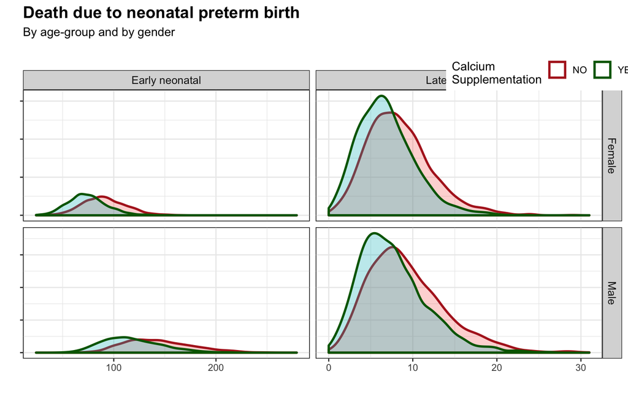

```r
final_dataset %>%
  filter(item =='death') %>%
  filter(item_outcome == 'neonatal_preterm_birth') %>%
  filter(item_age_group %in% c('early_neonatal',
                               'late_neonatal')) %>%
  ggplot(aes(value,
             color = ca_supp,
             fill = ca_supp))+
  geom_density(size = 1, alpha = .3)+
  facet_grid(gender ~ age_group, scales = 'free')+
  labs(title = 'Death due to neonatal preterm birth',
       subtitle = 'By age-group and by gender\n\n',
       color = 'Calcium \nSupplementation',
       x = '', y = '')+
  guides(fill = FALSE)+
  theme_bw()+
  scale_color_manual(values = c('firebrick', 'darkgreen'))+
  theme(legend.position = c(.9,1.065),
        legend.direction = 'horizontal',
        strip.text = element_text(size = 10),
        axis.text.y = element_blank(),
        plot.title = element_text(face = 'bold', size = 15),
        panel.background = element_rect(colour = 'black'))
```

#### rerun draft_2 to get final dataset for the following steps

```r
final_dataset %>% glimpse()
```

```
## Observations: 5,489,254
## Variables: 18
## $ item                                            <chr> "death", "death", "de…
## $ item_outcome                                    <chr> "neonatal_preterm_bir…
## $ gender                                          <fct> Male, Male, Male, Mal…
## $ lbw_sg_cat                                      <chr> NA, NA, NA, NA, NA, N…
## $ exposed_in                                      <chr> NA, NA, NA, NA, NA, N…
## $ item_age_group                                  <chr> "early_neonatal", "ea…
## $ total_population_untracked                      <dbl> 9623, 9561, 9626, 959…
## $ total_population_tracked                        <dbl> 12221, 12061, 12081, …
## $ total_population                                <dbl> 21844, 21622, 21707, …
## $ total_population_living                         <dbl> 10853, 10522, 10728, …
## $ total_population_dead                           <dbl> 1368, 1539, 1353, 139…
## $ input_draw                                      <dbl> 928, 590, 146, 465, 4…
## $ random_seed                                     <dbl> 97, 97, 2, 58, 2, 80,…
## $ simulation_run_time                             <dbl> 9960.960, 9948.302, 1…
## $ calcium_supplementation_intervention.proportion <chr> "0", "1", "1", "1", "…
## $ value                                           <dbl> 120, 95, 90, 94, 181,…
## $ age_group                                       <fct> Early neonatal, Early…
## $ ca_supp                                         <fct> NO, YES, YES, YES, YE…
```

```r
final_dataset %>% head
```

```
## # A tibble: 6 x 18
##   item  item_outcome gender lbw_sg_cat exposed_in item_age_group
##   <chr> <chr>        <fct>  <chr>      <chr>      <chr>
## 1 death neonatal_pr… Male   <NA>       <NA>       early_neonatal
## 2 death neonatal_pr… Male   <NA>       <NA>       early_neonatal
## 3 death neonatal_pr… Male   <NA>       <NA>       early_neonatal
## 4 death neonatal_pr… Male   <NA>       <NA>       early_neonatal
## 5 death neonatal_pr… Male   <NA>       <NA>       early_neonatal
## 6 death neonatal_pr… Male   <NA>       <NA>       early_neonatal
## # … with 12 more variables: total_population_untracked <dbl>,
## #   total_population_tracked <dbl>, total_population <dbl>,
## #   total_population_living <dbl>, total_population_dead <dbl>,
## #   input_draw <dbl>, random_seed <dbl>, simulation_run_time <dbl>,
## #   calcium_supplementation_intervention.proportion <chr>, value <dbl>,
## #   age_group <fct>, ca_supp <fct>
```

```r
final_dataset %>% count(item)
```

```
## # A tibble: 26 x 2
##    item                                                                        n
##    <chr>                                                                   <int>
##  1 death                                                                  2.56e5
##  2 diarrheal_diseases_event_count                                         4.00e3
##  3 diarrheal_diseases_prevalent_cases_at_sim_end                          4.00e3
##  4 hemolytic_disease_and_other_neonatal_jaundice_event_count              4.00e3
##  5 hemolytic_disease_and_other_neonatal_jaundice_prevalent_cases_at_sim_… 4.00e3
##  6 low_birth_weight_and_short_gestation                                   4.64e6
##  7 lower_respiratory_infections_event_count                               4.00e3
##  8 lower_respiratory_infections_prevalent_cases_at_sim_end                4.00e3
##  9 measles_event_count                                                    4.00e3
## 10 measles_prevalent_cases_at_sim_end                                     4.00e3
## # … with 16 more rows
```

### crude death rate:

I thouhgt this is the way to calculate CDR by first, selecting only person_time rows…

```r
crude_rate <- final_dataset %>%
  filter(item == 'person_time') %>%
  mutate(crude_death_rate_per_100000 = (total_population_dead / total_population_tracked)* 100000) %>%
  select(item, gender, item_age_group,
         total_population_dead, total_population_tracked,
         crude_death_rate_per_100000, ca_supp)
```

..and then try to plot CDR density plot by calcium supp, gender and age groups.

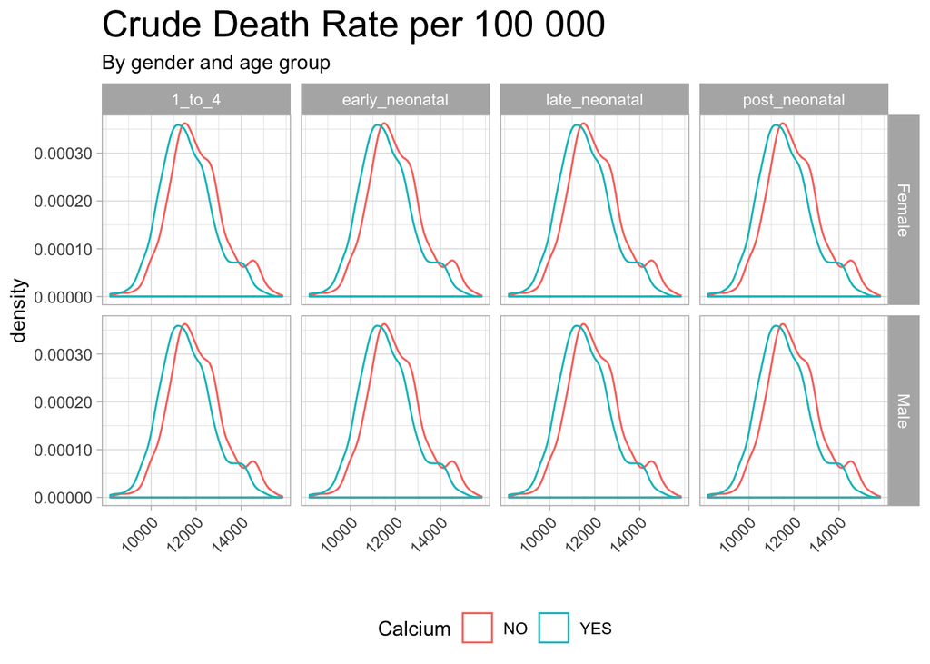

```r
crude_rate %>%
  ggplot(aes(crude_death_rate_per_100000,
             color = ca_supp))+
  geom_density()+
  facet_grid(gender ~ item_age_group)+
  theme_light()+
  scale_x_continuous(breaks = c(10000, 12000, 14000))+
  scale_y_continuous(labels = label_number())+
  labs(title = 'Crude Death Rate per 100 000',
       subtitle = 'By gender and age group',
       color = 'Calcium',
       x='')+
  theme(plot.title = element_text(size = 20),
        axis.text.x = element_text(angle = 45,
                                   hjust = 1),
        legend.position = 'bottom')
```